# Partisan Differences in Natural-Hazard Risk

Evidence from registered voters in Florida

Haoluan Wang

University of Miami

Phillip Khaskin

Federal Reserve Bank of Dallas

James Xinde Ji

University of Guelph

Weizhe Weng

University of Guelph

Leanna Navo

University of Miami

June 2026

## Geographic heterogeneity in hazard risk

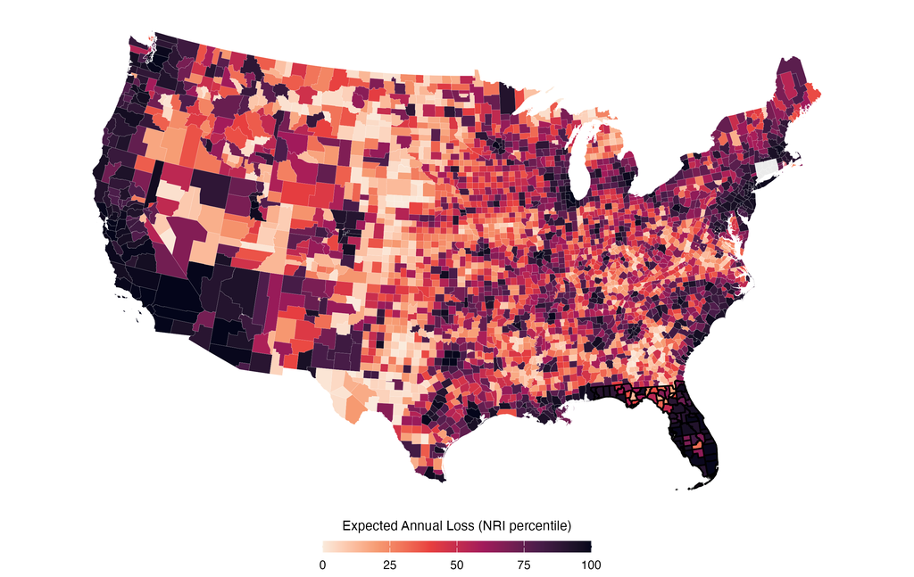

Source: FEMA

## The cost of bearing that risk is large — and socialized

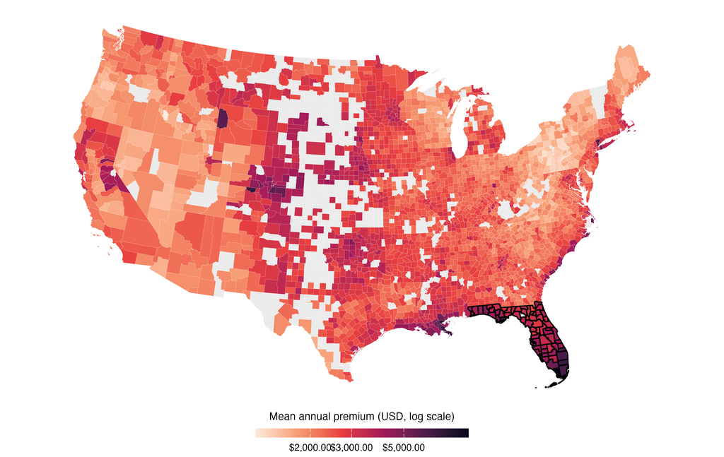

County homeowner premium from Keys and Mulder (2025)

## Americans are already sorted by party across geography

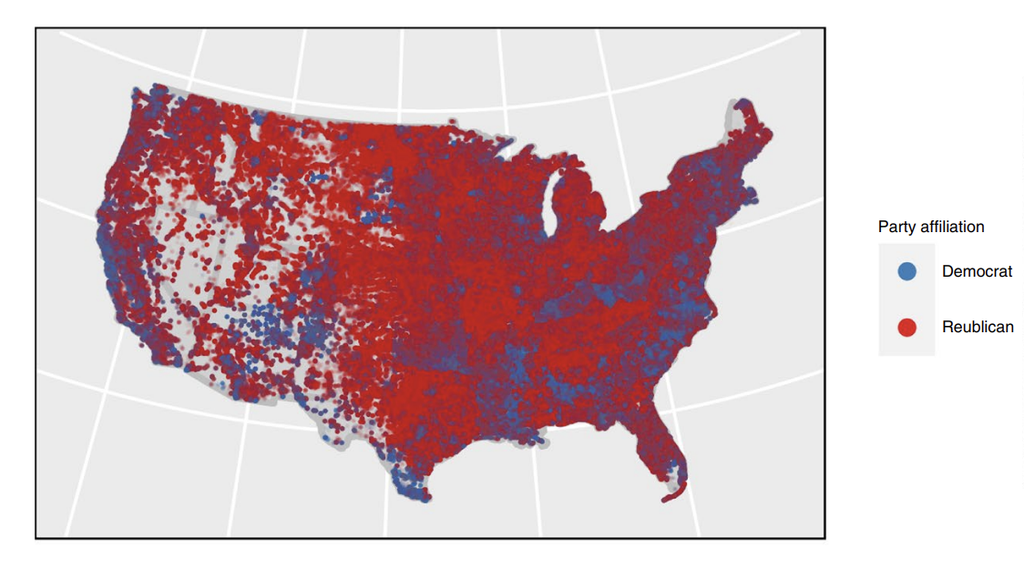

Partisan residential segregation of 180M registered voters (Brown & Enos 2021, *Nature Human Behaviour*). Red = Republican, blue = Democrat.

## Ideological divergence

What we build on

- **Beliefs:** Ideological differences are correlated with climate and disaster risk beliefs (McCright & Dunlap 2011; Botzen et al. 2016; Bakkensen & Barrage 2022).
- **Sorting:** Partisans sort and are segregated by ideology (Brown & Enos 2021) and coastal climate risk (Bernstein et al. 2022), paralleling partisan gaps in other decision-making domains (e.g., Ke 2024).
- **What we document:** whether these combine into a partisan gap in *realized* natural-hazard exposure — in where partisans **live** and where they **migrate**.

## Two concurrent patterns in Florida

The puzzle is in the headlines

People are moving *into* risk — and insurance is buckling

“Americans are flocking to U.S. regions most threatened by climate change”CBS News · 2024

“Florida home insurance market collapses 78% as climate risks overwhelm system”Yahoo Finance · 2025

“How climate risks are putting home insurance out of reach”Yale Environment 360 · 2024

Florida is rapidly turning Red

“Florida Republicans surpass Democrats in voter registration for first time”The Hill · 2021

“Florida GOP flips Miami-Dade in voter registration for first time in history”The Hill · 2025

“Trump is the first Republican candidate to win Miami-Dade County since 1988”WLRN · 2024

## Florida is where the right-ward shift is fast

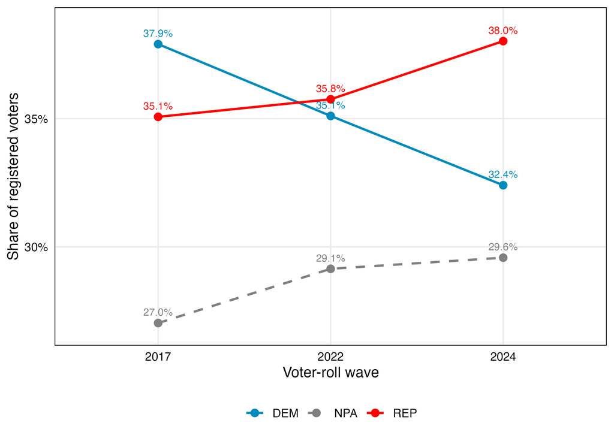

Florida registered-voter party shares, three waves. DEM 37.9 → 32.4; REP 35.1 → 38.0.

## Three research questions

What we ask

1. Does political ideology predict residential disaster risk — the risk where a voter *lives*?
2. When voters *move*, does deology predict the level of disaster risk they are moving to?
3. When a voter’s ideology *changes*, does their disaster risk exposure **change with it**?

## What could drive such a gap?

Candidate mechanisms — not mutually exclusive

- **Climate / risk beliefs** — more-conservative voters discount the hazard and accept it.
- **Equilibrium pricing** — riskier places are cheaper, so price-sensitive movers sort in.
- **Ideological affinity** — voters move toward politically like-minded places, and the hazard comes bundled.
- **Taste for amenity** — demand for the coast (or for rural, inland living) that carries hazard as a byproduct.

## This paper in one slide

Five findings we document

- Republicans live in riskier tracts (DEM < NPA < REP); the ordering survives conditioning and *relocates* from neighborhoods to counties.
- Ideology measured *before* a move predicts the destination’s risk — a 0.78-point Republican–Democrat gap.
- Migration runs through the *composition* of places: same direction everywhere, a different channel by hazard.
  - **Coast:** ideological affinity — Republicans into redder, riskier coastal counties.
  - **Inland:** urbanicity and education — not price (the housing price channel ≈ 0).
- Within a voter, the full ladder of party transitions tracks risk: rightward-shift voters moves *into* risk, leftward-shift voters moves *out of* risk
- Migration lands movers in the below-actuarial state-insurer (Citizens) range: ≈ $29–35/yr per mover in priced premium — a socialized cost, not a transfer between parties.

## What we contribute to

Three literatures

- **Ideological residential sorting.** Brown & Enos (2021); Brown (2024); Brown et al. (2025) document segregation and neighborhood conversion by party.
  - We add the **physical-hazard** coordinate, and the *dynamic* margin — the migration and the within-voter realignment, not only the cross-section.
- **Climate beliefs & coastal real estate.** Bernstein et al. (2022); Bakkensen & Barrage (2022); Bakkensen & Ma (2020) tie ideology and beliefs to coastal prices and sorting.
  - We give the **revealed-sorting complement across multiple hazards** in a near-universe panel, and show the gap is largely composition, not separably belief.
- **Climate migration & disaster political economy.** Sheldon & Zhan (2022); Hino et al. (2017); Healy & Malhotra (2009) study who moves under hazard and how disasters shape policy.
  - We add **political ideology as a margin of climate migration**, and connect the migration to a socialized-insurance externality.

## Data: the Florida voter file

Where the data come from

- **Florida voter file** (Division of Elections) — monthly administrative records of *every* registered voter: a stable voter ID (tracks the same person over time), party registration, residence address, and demographics (sex, race, age).
- **Three waves**, each residence geocoded — Feb 2017, Jun 2022, Nov 2024 (~13–16M voters) — so we see where voters live and, for movers, where they go.
- **Tract characteristics** (Census / ACS) — each residence also carries its census tract’s income, home value, education, and urbanicity (the neighborhood controls).

| Wave | N voters | DEM % | NPA % | REP % |
| --- | --- | --- | --- | --- |
| 2017 | 13,498,660 | 37.9 | 27.0 | 35.1 |
| 2022 | 15,154,821 | 35.1 | 29.1 | 35.8 |
| 2024 | 15,972,441 | 32.4 | 29.6 | 38.0 |

## The outcome: FEMA’s Expected Annual Loss (EAL)

- **What it is:** FEMA’s National Risk Index, $\text{EAL}=\text{Exposure}\times\text{frequency}\times\text{historic loss ratio}$. We use the **0–100 percentile score** — a tract’s risk rank among all U.S. tracts.
- **Policy-relevant:** FEMA’s official measure for baselining community risk and targeting mitigation funding.
- **Ex ante, not realized:** a fixed attribute of the *location’s* hazard environment, not insurance payouts — which depend on coverage, claims, and which storms strike (all endogenous to wealth and party).

## Where the hazards are: overall and three Florida perils

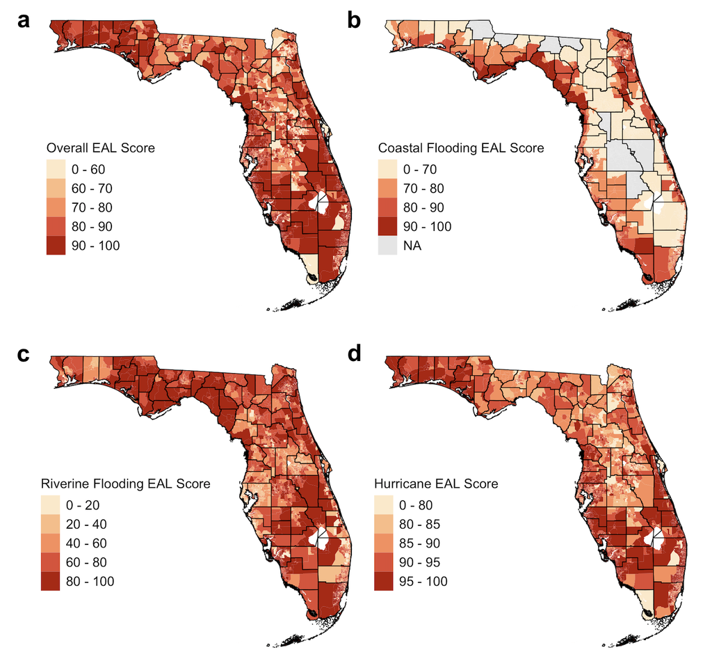

Census-tract EAL percentile: (a) overall, (b) coastal flood, (c) riverine flood, (d) hurricane. County borders in black; grey = not applicable.

## Florida’s partisan and hazard geographies

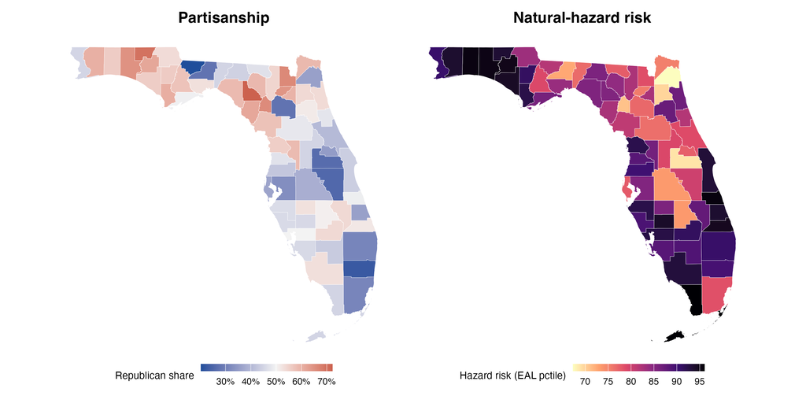

County Republican registration share (left) and mean voter hazard risk, EAL percentile (right), 2024.

## The gap is visible without a regression

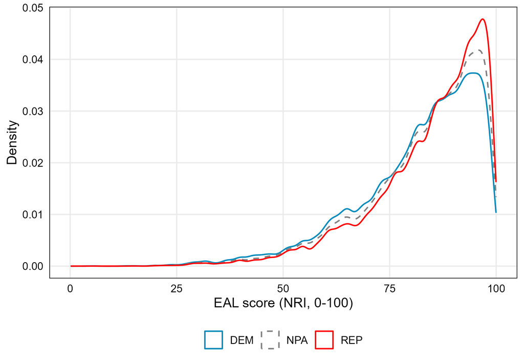

Tract EAL percentile by party, 2017. Monotone DEM < NPA < REP.

## Research questions and designs

Each is answered at a different comparison; each design strips a successively stronger set of confounders.

| Research question | Design | Identifying comparison |
| --- | --- | --- |
| **Q1.** Does ideology predict residential risk? | Level (cross-section) | Within county, by wave, differing in ideology — *observational* |
| **Q2.** When voters **move**, toward different risk? | Migration (pre-move ideology) | Movers leaving the same county, differing in pre-move ideology |
| **Q3.** Does an ideology **change** track a risk change? | Within-voter realignment | First difference; individual heterogeneity cancels |
| **Mechanism.** *Why* do they move? | Composition decomposition | Destination composition, level-matched |

# Does political ideology predict residential disaster risk?

Question 1 · level

## Question 1 — the within-county comparison

Disaster-risk level by ideology, conditional on demographics, within county — a cross-section, estimated at each wave.

$$\mathrm{EAL}_{inc}=\beta_{R}\,\mathbb{1}[\mathrm{REP}_{inc}]+\beta_{D}\,\mathbb{1}[\mathrm{DEM}_{inc}]+X_{inc}'\gamma+\delta_c+\varepsilon_{inc}$$

- Voter $i$ lives in tract $n$ of county $c$; $\mathrm{EAL}_{inc}$ = voter $i$’s tract EAL, a fixed tract attribute.
- $\mathrm{REP}_{inc},\mathrm{DEM}_{inc}$ = party of voter $i$ (in tract $n$, county $c$), NPA omitted.
- $X_{inc}$ = sex, race, age.
- $\delta_c$ = county FE; cluster on county; estimated at each wave (2017 / 2022 / 2024).

Identifying comparison Two voters in the **same county** (within a wave), same demographics, differing in ideology — a **within-county, observational** comparison. β<sub>R</sub> − β<sub>D</sub> is reference-invariant.

## It survives conditioning — and the pole switches by hazard

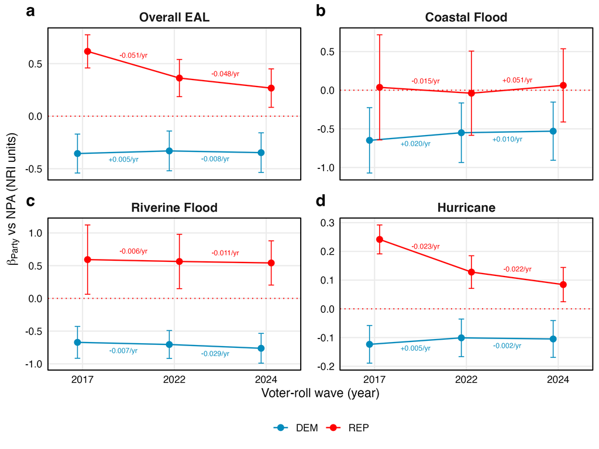

## Relocation, not widening: from neighborhoods to counties

Our headline (previous slide) is the *within*-county gap. Decomposing the total gap shows how much risk sorting now sits *between* counties — and that share is rising.

$$\text{gap}^{\text{total}}_{t}=\text{gap}^{\text{between}}_{t}+\text{gap}^{\text{within}}_{t}$$

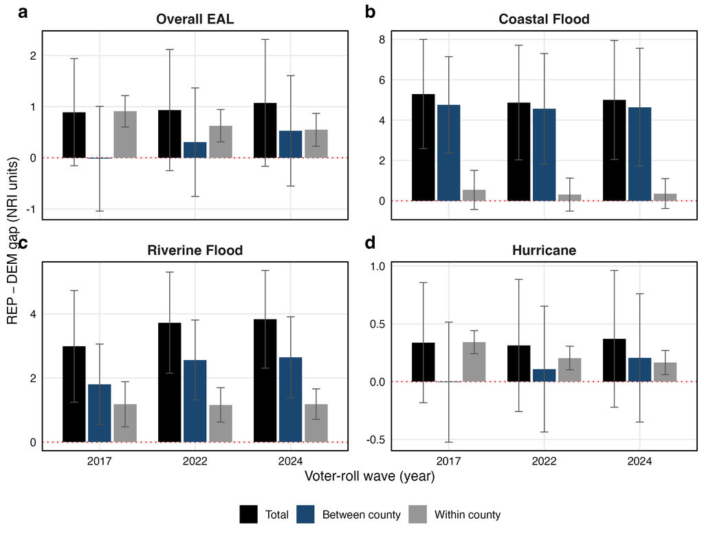

# When voters move, does ideology predict the risk they move to?

Question 2 · migration

## Question 2 — where movers go, by pre-move ideology

The risk content of the move, on party fixed before it. One first difference per mover, stacked over both episodes.

$$\begin{aligned}
\Delta\mathrm{EAL}_{i}&=\beta_{R}\,\mathbb{1}[\mathrm{REP}_{inc}]+\beta_{D}\,\mathbb{1}[\mathrm{DEM}_{inc}]+X_{inc}'\gamma+Z_{nc,\,t-1}'\lambda+\delta_{c,\,t-1}+\varepsilon_{inc}\\[3pt]
\Delta\mathrm{EAL}_{i}&=\underset{\text{destination, }t}{\mathrm{EAL}_{in'c'}}-\underset{\text{origin, }t-1}{\mathrm{EAL}_{inc}}
\end{aligned}$$

- Voter $i$ moves from origin tract $nc$ ($t{-}1$) to destination tract $n'c'$ ($t$); $\Delta\mathrm{EAL}_i$ is a pure place difference (EAL is a fixed tract attribute).
- $\mathrm{REP}_{inc},\mathrm{DEM}_{inc}$ = **origin (predetermined) party**, fixed before the move.
- $Z_{nc,\,t-1}$ = **origin-tract** amenities (economic, socio-demographic, flood-risk); $X_{inc}$ = sex, race, age.
- $\delta_{c,\,t-1}$ = origin-county FE; two-way cluster (origin + destination county); pooled over both episodes.

Identifying comparison Movers leaving the **same origin county**, from origins with similar economic, socio-demographic, and flood-risk profiles, differing in **pre-move ideology**. Destination characteristics are an equilibrium outcome of the move, so they are left unrestricted — conditioning on them would be a bad control.

## Party before the move predicts the move’s risk

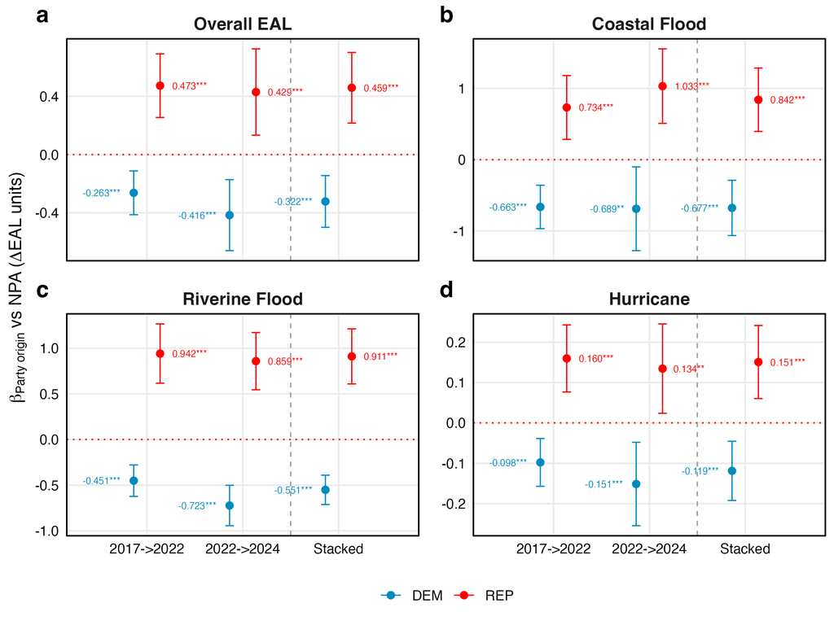

## Two phenomena: migration vs neighborhood sorting

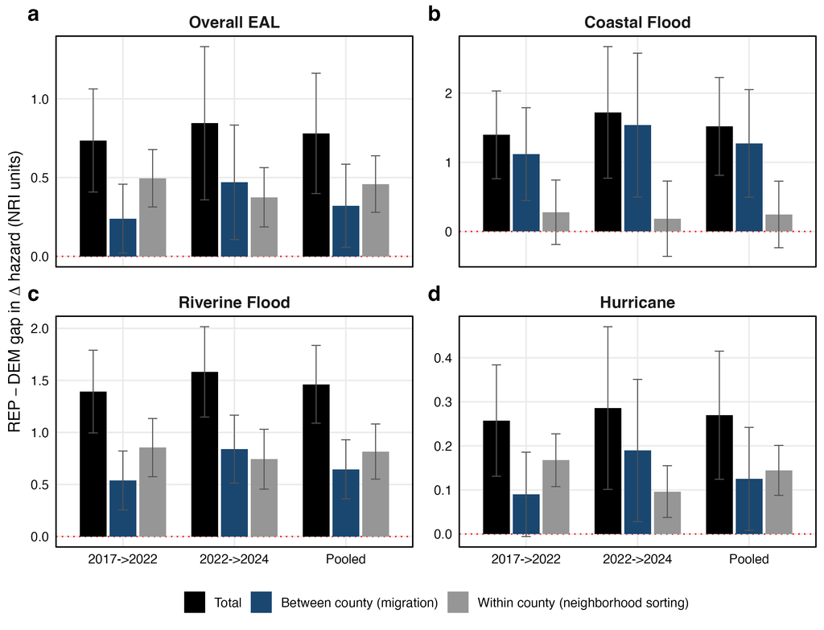

# Mechanism: why did they move?

The channel behind the migration

## Coastal sorting tracks ideological affinity; inland tracks composition

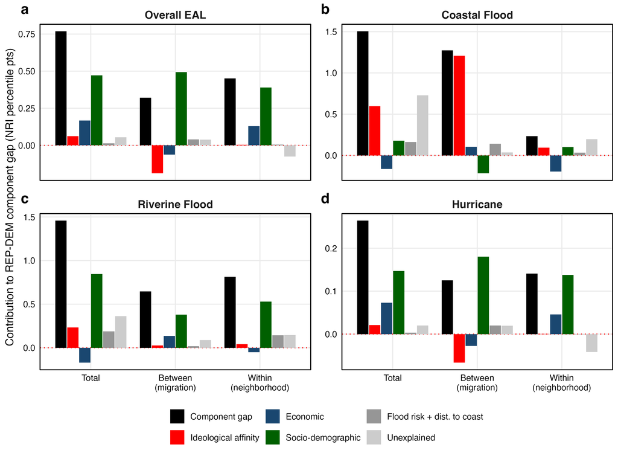

## There is no neighborhood ideological re-sorting

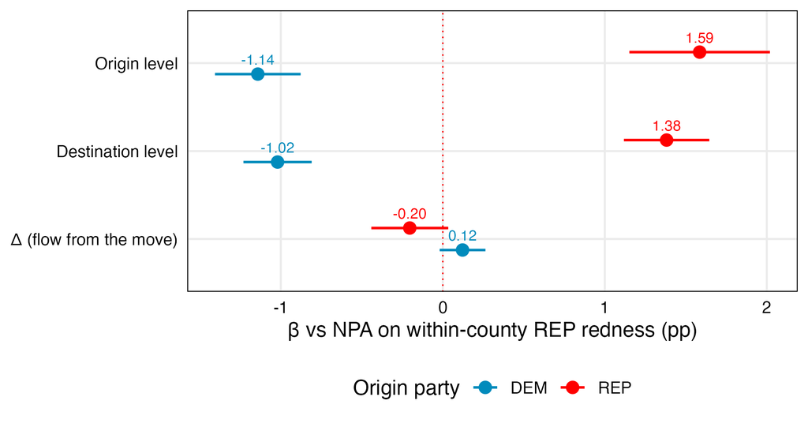

## The inland channel, made concrete

[figure not shown]

## Coastal sorting is two-sided: Republicans in, Democrats out

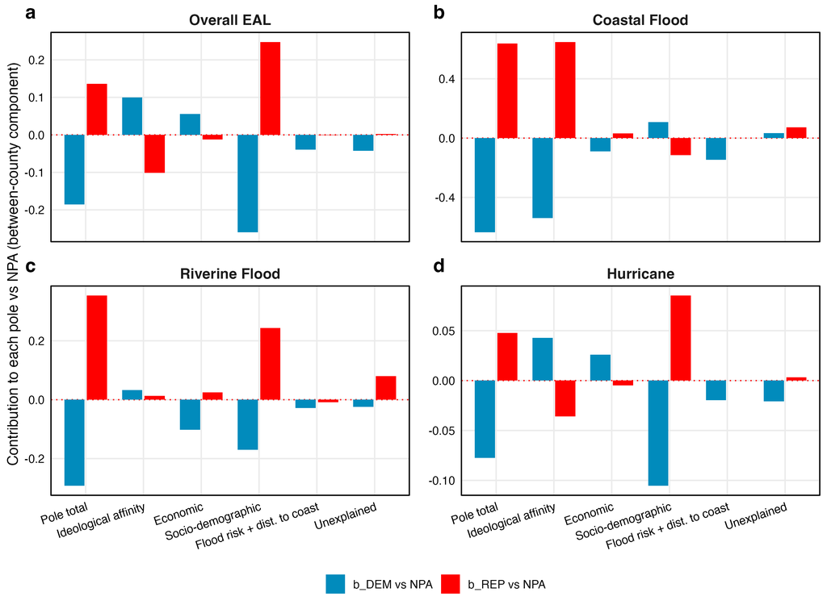

# When a voter’s ideology changes, does their disaster risk change correspondingly?

Question 3 · within-voter realignment

## Question 3 — the within-voter comparison

When a voter’s own party changes, does their risk change with it? One first difference per mover, stacked over both episodes.

$$\begin{aligned}
\Delta\mathrm{EAL}_{i}&=\sum_{k}\theta_k\,\mathbb{1}[\mathrm{transition}_{i}=k]+X_{inc}'\gamma+\delta_{c,\,t-1}+\varepsilon_{inc}\\[3pt]
\Delta\mathrm{EAL}_{i}&=\underset{\text{destination, }t}{\mathrm{EAL}_{in'c'}}-\underset{\text{origin, }t-1}{\mathrm{EAL}_{inc}}
\end{aligned}$$

- $\mathrm{transition}_i$ = one of the **9** possible origin$\to$destination party combinations (party at $t{-}1\to$ party at $t$); stayed-NPA (N→N) reference.
- Differencing the outcome sweeps voter $i$’s **unobserved** fixed effect (risk tolerance, wealth, place attachment); for two waves this *is* the individual-FE estimator.
- $X_{inc}$ = sex, race, age.
- $\delta_{c,\,t-1}$ = origin-county FE; two-way cluster; pooled over both episodes.

Why this design exists The only design that nets out a fixed “higher-risk type.” Among voters whose ideology *changed*, did their risk change *with* it?

## Risk rises with a rightward change, falls faster with a leftward one

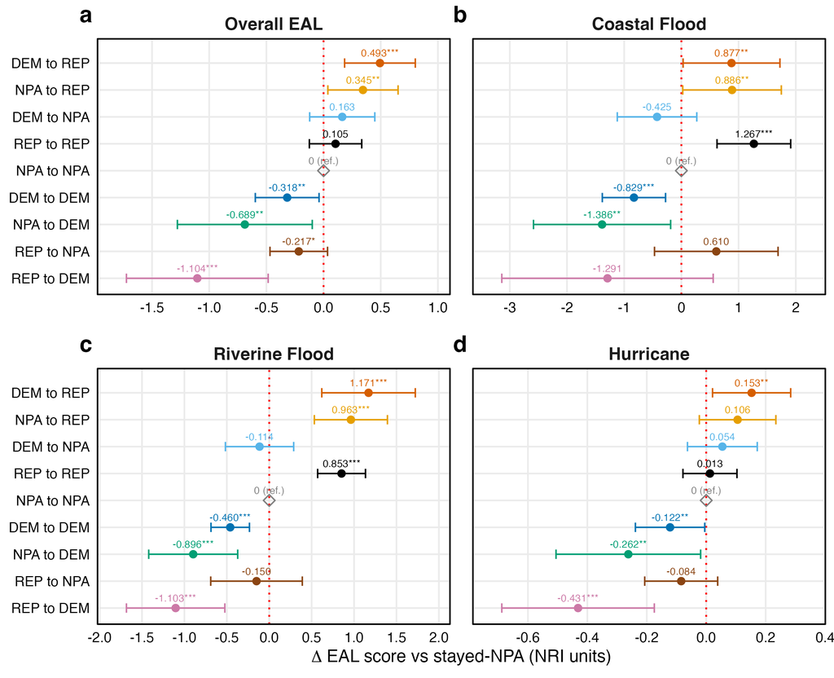

# Who is sorting — and who pays?

Heterogeneity & the fiscal coda

## Working-age voters drive the sorting; senior party change does not move risk

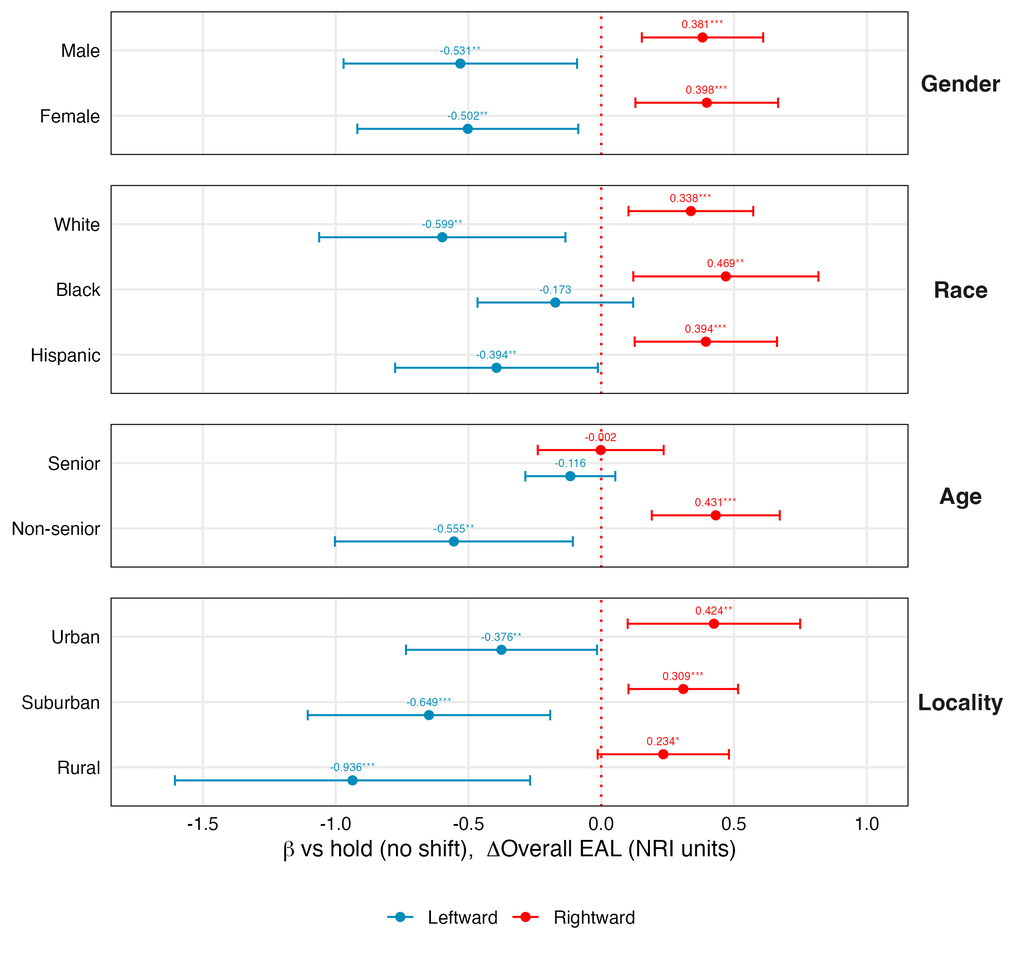

## Migration raises exposure in the subsidized-insurance range

Turning the migration gap into a dollar figure

1. **Price the risk.** Fit the Keys and Mulder (2025) county homeowner premium on county EAL score → a market premium–risk gradient, γ ≈ $37–45 per EAL point.
2. **Apply it to the gap.** The predetermined-party migration gap (0.78 EAL points) × γ ≈ $29–35 per mover per year in priced premium.
3. **Read it as a lower bound.** The increment moves voters into the below-actuarial Citizens range, so the socialized share lands on the statewide assessment base — a fiscal externality, not a partisan transfer by design.

## County risk and premiums track together

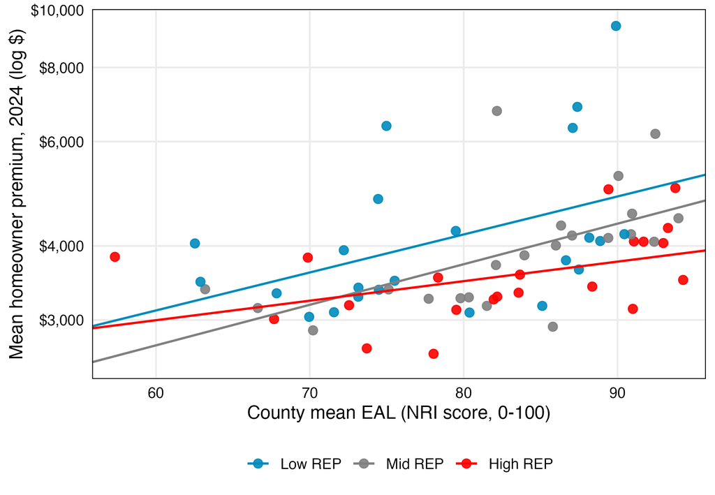

County mean EAL vs mean homeowner premium (Keys and Mulder (2025)), shaded by Republican vote-share tertile.

## Conclusion

What we find

- Observational: DEM < NPA < REP in natural-hazard exposure — Republicans live in riskier tracts.
- When they move, Republicans sort *toward* risk and Democrats *away* from it.
- A voter’s own ideological shift partially predicts that migration into or out of risk.
- Drivers are hazard-specific: ideological affinity at the coast (consistent with, not proof of, climate-belief differences); urbanicity and education inland.

## Implications

The one-sentence version

Partisans don’t move *toward risk* — they move toward red coasts and rural inland places, and the hazard comes bundled.

- Ideological affinity at the coast; urbanicity and education inland.
- Not price (economic ≈ 0 everywhere); not separably belief.
- Relocation, not widening. Small per person; systematic, directional, asymmetric in aggregate.

# Appendix

Depth on demand

National generalization · identification ledger · raw migration & direction · mean-reversion ladder · raw 9-cell & composition · selective migration / assimilation · spatial SEs, Oster & the senior nulls · dollar-EAL caveat · full heterogeneity · open questions.

## The Florida pattern generalizes nationally

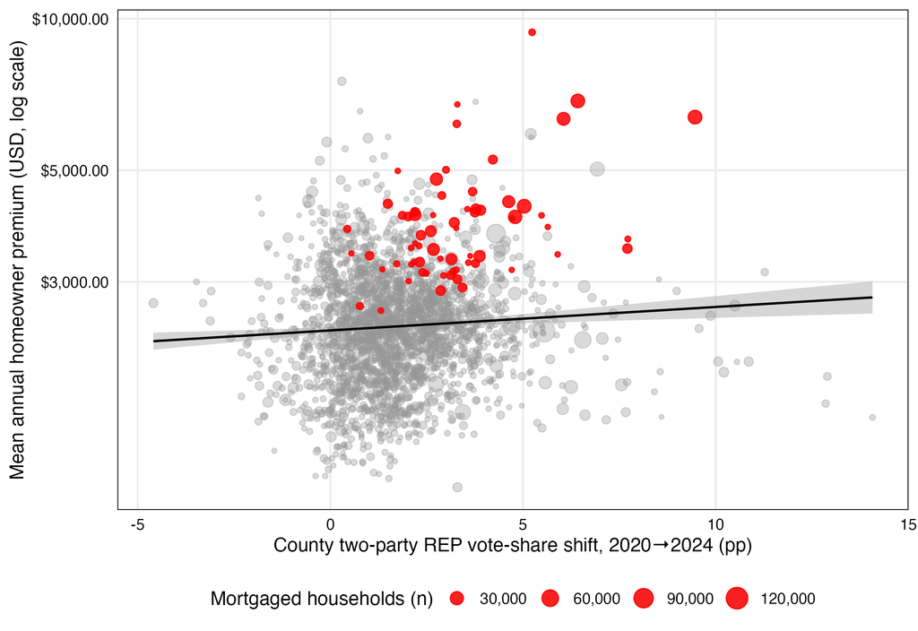

REP-shift × insurance premium (2020→24; Keys and Mulder (2025)). Florida in the high-shift, high-cost corner.

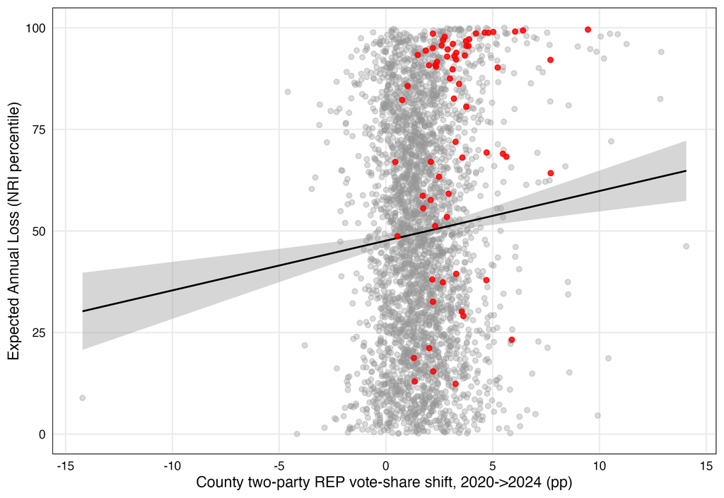

REP-shift × Expected Annual Loss (2020→24; FEMA NRI). Florida in the high-shift, high-hazard corner.

← back to the opener · ← back to why Florida

## Identification ledger

Every coefficient lives in exactly one row — its design and the comparison that identifies it.

| Object | Identifying variation | What β is |
| --- | --- | --- |
| **Q1 level** (within-county) | Between-person, within county, by wave, cond. on X | Conditional mean EAL gap vs NPA, same county |
| **Q1 level** (no FE) | Between-person, statewide | Total gap incl. between-county composition |
| **Q2 migration** | Movers, same origin county, differing **pre-move** ideology | Forward-sorting association of pre-move ideology with the move’s risk |
| **Q3 within-voter realignment** | Within-voter first difference (heterogeneity cancels) | Mean ΔEAL of each transition vs stayed-NPA movers |
| **Mechanism** | β across columns; level-matched destination channels | Channel attribution (decomposition), held to the total gap |
| **Falsification** | Permutation; reverse-time placebo | Mechanical-validity floor; bound on forward share |

← back to strategy

## Raw migration and its direction

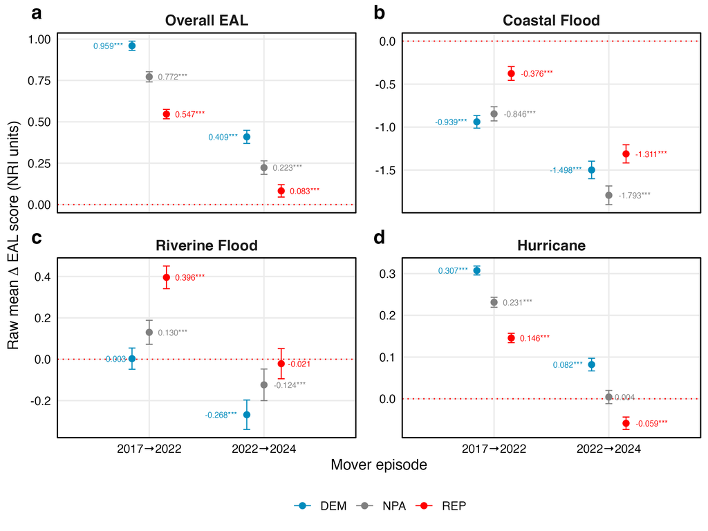

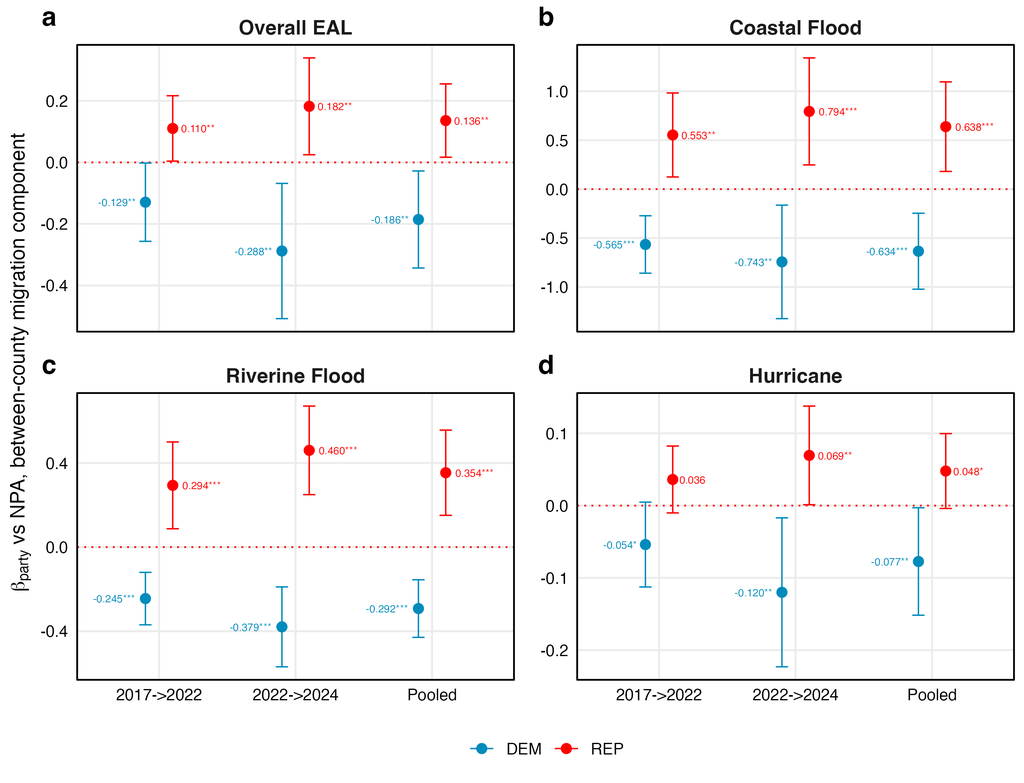

← back to the migration

## Mean-reversion ladder: origin controls *raise* the gap

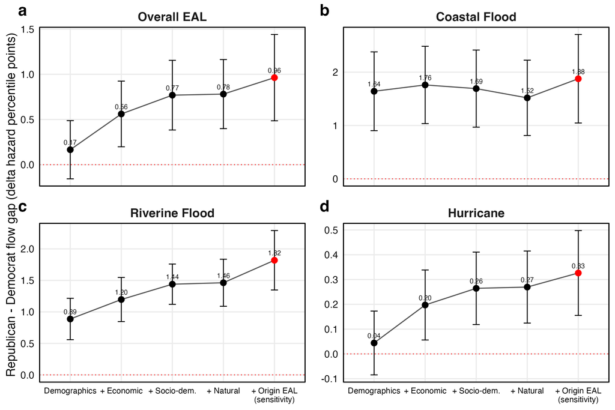

Republican − Democrat migration gap as predetermined origin amenities are added one group at a time. Overall EAL 0.17 → 0.78 (headline) → 0.96 (with origin EAL). The naive 0.17 is a lower bound: origin controls recover the gap mean reversion had masked.

← back to Q2 — migration · ← back to contributions

## The 9-cell in raw means & sample composition

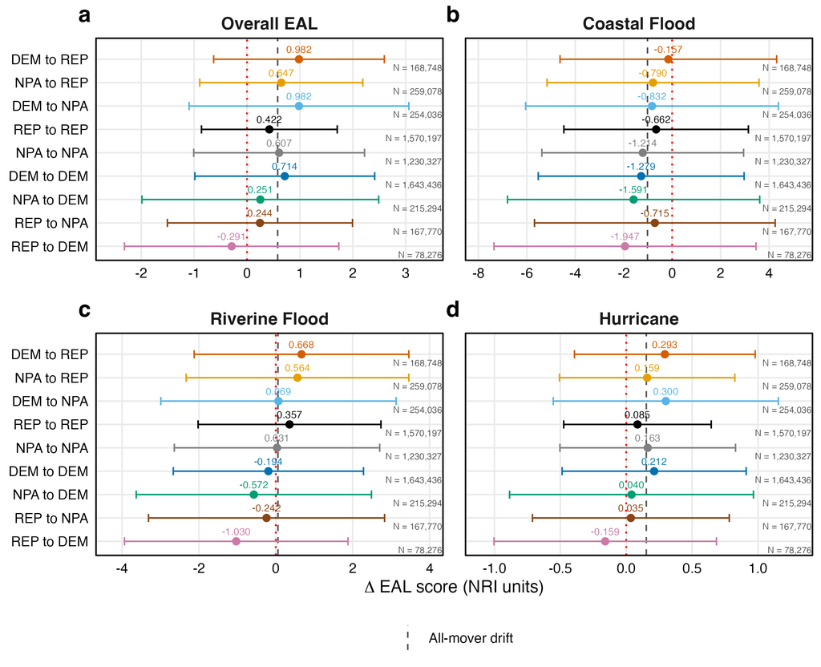

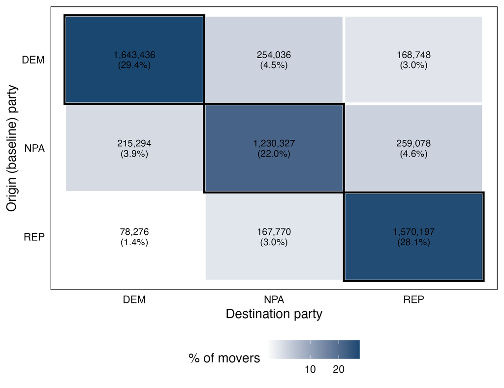

← back to the realignment

## The realignment asymmetry, three summaries

**Shift index** — every mover once:

| Hazard | Rightward (to GOP) | Leftward (to DEM) |
| --- | --- | --- |
| Overall EAL | 0.39 | -0.51 |
| Coastal Flood | 0.25 | -0.81 |
| Riverine Flood | 0.48 | -0.80 |
| Hurricane | 0.14 | -0.19 |

**Symmetry test** (R→D = D→R):

| Hazard | F | p | (R-to-D) - (D-to-R) |
| --- | --- | --- | --- |
| Overall EAL | 7.6 | 4.8e-04 | -1.60 |
| Coastal Flood | 2.6 | 7.8e-02 | -2.17 |
| Riverine Flood | 14.8 | 4.0e-07 | -2.27 |
| Hurricane | 6.2 | 2.0e-03 | -0.58 |

**Voter-FE panel** — three-wave within estimator:

| Hazard | REP | DEM | Within-voter gap |
| --- | --- | --- | --- |
| Overall EAL | 0.22 | -0.40 | 0.62 |
| Coastal Flood | 0.18 | -0.49 | 0.67 |
| Riverine Flood | 0.47 | -0.34 | 0.81 |
| Hurricane | 0.07 | -0.14 | 0.21 |

← back to the realignment

## Selective migration: party and place are revised together

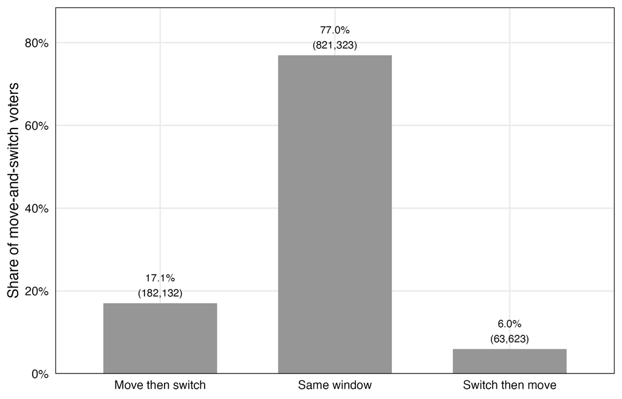

← back to the migration · ← back to the realignment

## Spatial SEs, Oster bounds, and the senior nulls

Where the weight goes: the robust legs, stated plainly.

- **Oster (2019):** the Democratic-vs-NPA level gap is robust (δ* = 3.70); the **Republican-vs-NPA level is fragile (δ* = 0.85)** — consistent with Democrats driving the coastal gap.
- **Cinelli–Hazlett:** robustness value ≈ 0.002 — precise at N ≈ 15M, but a small partial-R², the small-per-person point in inference form.
- **Conley spatial-HAC:** SEs inflate ~70% at the adjacent-county scale; β<sub>REP</sub> remains statistically significant (t ≈ 4–9).
- **Permutation (B = 999):** the observed migration gap sits ~12 null SDs out, randomization p < 0.001.

Two clean senior nulls The level (Q1) age cut and the within-voter realignment: a 65+ voter’s party change moves risk in *neither* direction. The senior *migration* gap is attenuated (0.45 vs 0.85), not null — so it is two clean nulls plus an attenuated migration gap, stated honestly.

← back to Q1 — level

← back to the data

## Full heterogeneity

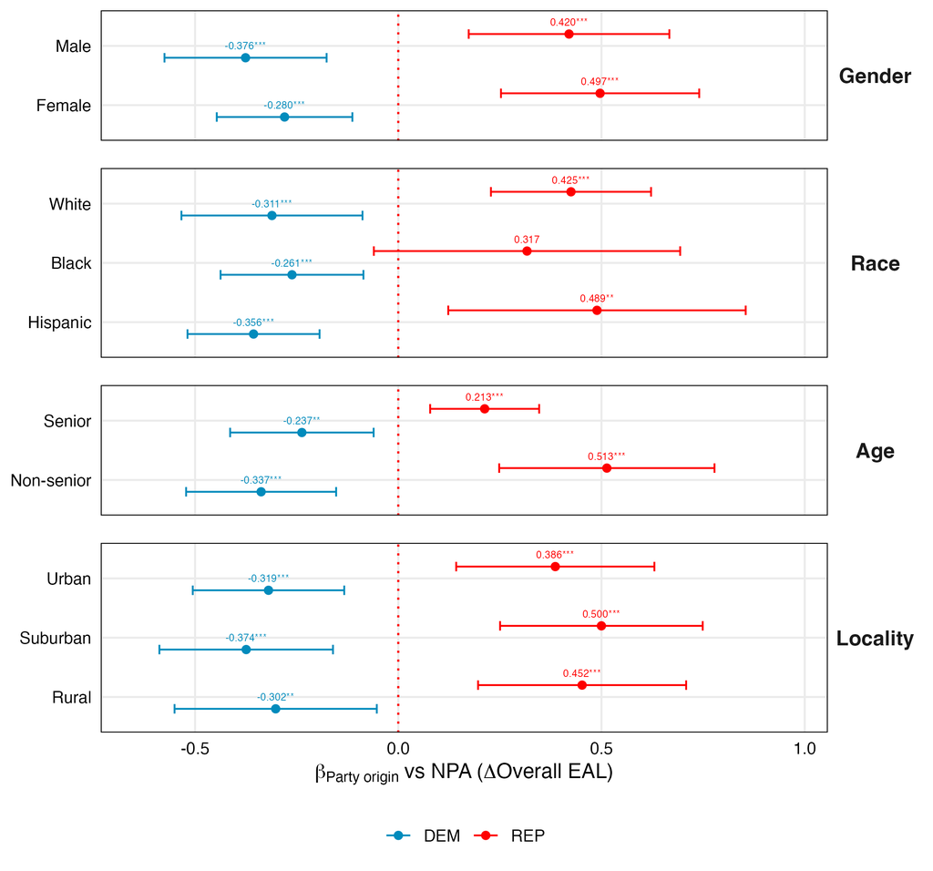

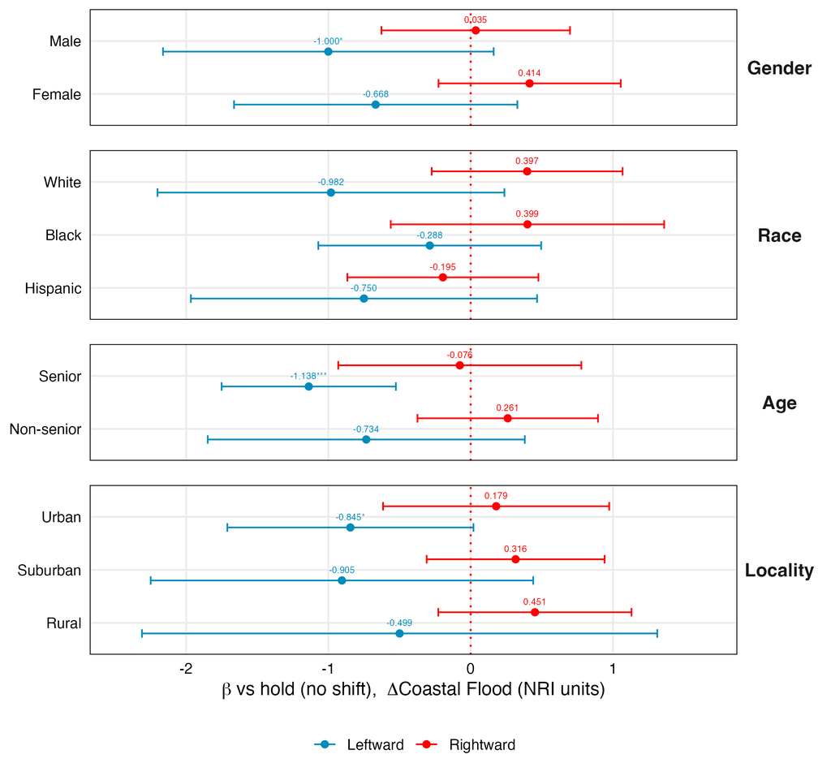

← back to who sorts

## Open questions

- **The pole switches by hazard.** Overall EAL is a Democratic-side phenomenon; the coastal migration is Republican-side. This is the per-hazard structure of the result, not an inconsistency — so we always name the hazard.
- **Reverse-time placebo larger than predetermined party.** Expected under joint choice; it bounds the forward-sorting share and is precisely why we use the predetermined design.
- **Belief is unidentified by design.** We cannot attribute the sorting to climate belief versus lifestyle — the time-invariant part differences out and the rest is belief-ambiguous. The honest frontier is a belief-elicitation design (Bakkensen & Barrage 2022); we are the revealed-sorting complement.
- **Next steps:** a Citizens-participation welfare measure; a hedonic price test; a type-specific conditional-logit location-choice model to separate the bundled channels.

← back to the realignment